# Introduction to ggplot

## Plotting with `ggplot`

Layers:

1. Data: The dataset being summarised
2. Geometry: The type of plot
3. Aesthetic mapping: Variables mapped to visual cues, such as x/y-axis values and colour

Others:

- Scale
- Labels, Title, Legend
- Themes/Styles

### Basics

```r
library(tidyverse)
data(murders)
```

Without describing anything, `ggplot` produces a blank slate

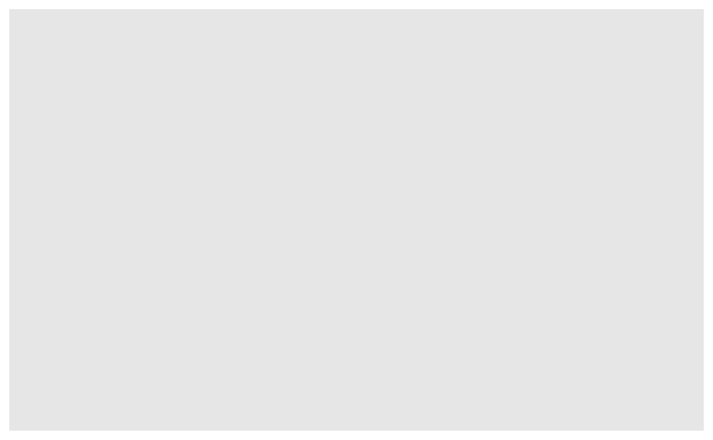

```r
murders %>% ggplot()
```

Printing the `ggplot` object gives the same output

```r
p <- ggplot(data = murders)
class(p)
```

```
[1] "gg"     "ggplot"
```

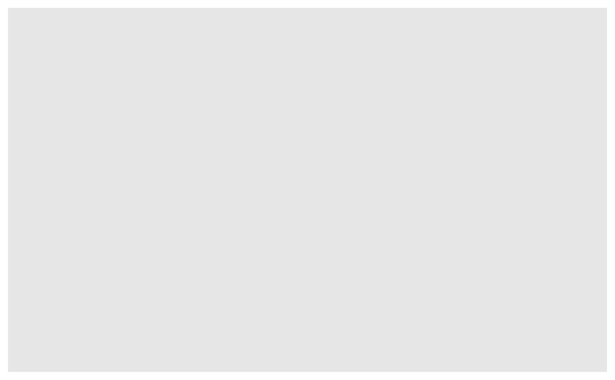

```r
print(p)
```

### Layers

Here we add a geometry layer, assigning column names to x and y

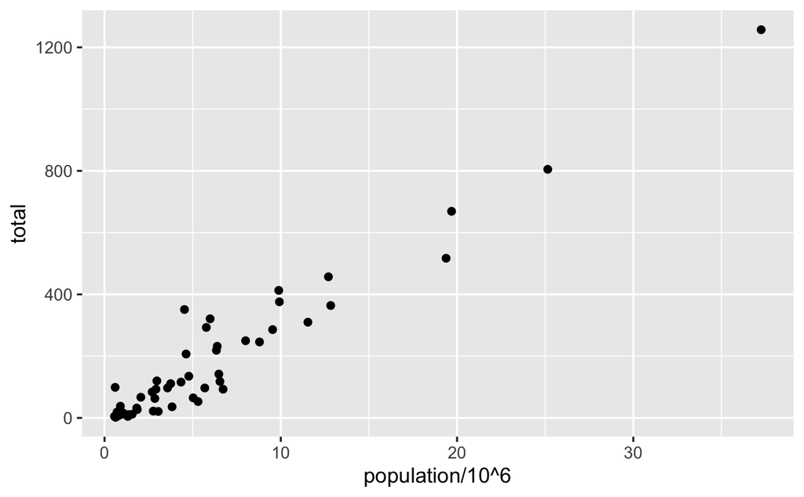

```r
murders %>% ggplot() +
  geom_point(aes(x = population/10^6, y = total))
```

The same effect can be achieved by using the plot object that we had created, `p`.

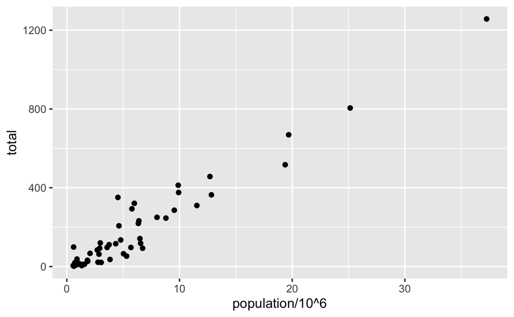

```r
p + geom_point(aes(x = population/10^6, y = total))
```

… and we can add more layers

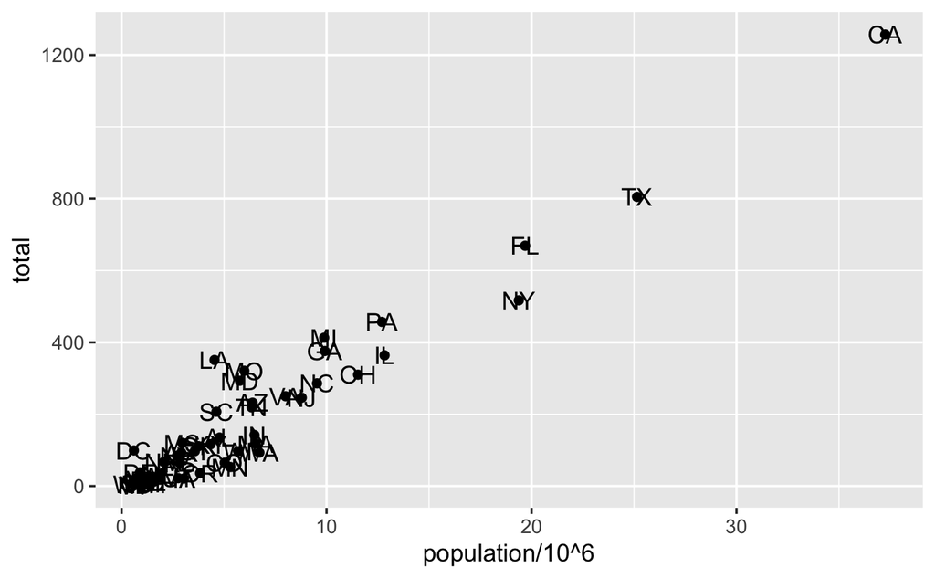

```r
p + geom_point(aes(population/10^6, total)) +
    geom_text(aes(population/10^6, total, label = abb))
```

Tinkering with the layers byt passing further arguments, outside of `aes()`

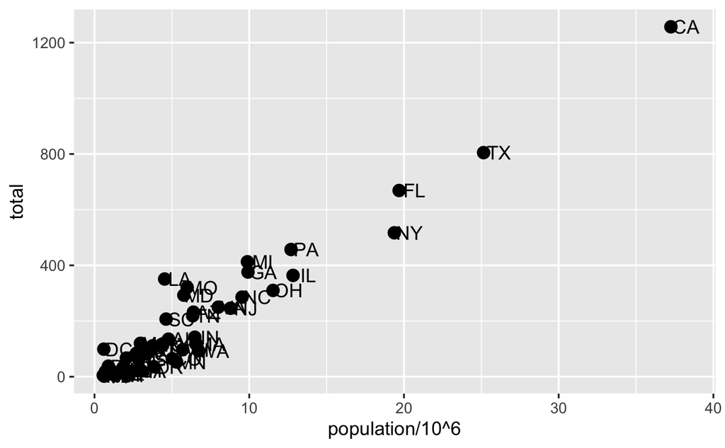

```r
p + geom_point(aes(population/10^6, total), size = 3) +
    geom_text(aes(population/10^6, total, label = abb), nudge_x = 1)
```

The code can be simplified by setting a global mapping on `p`. Note that local mappings override default or global mappings.

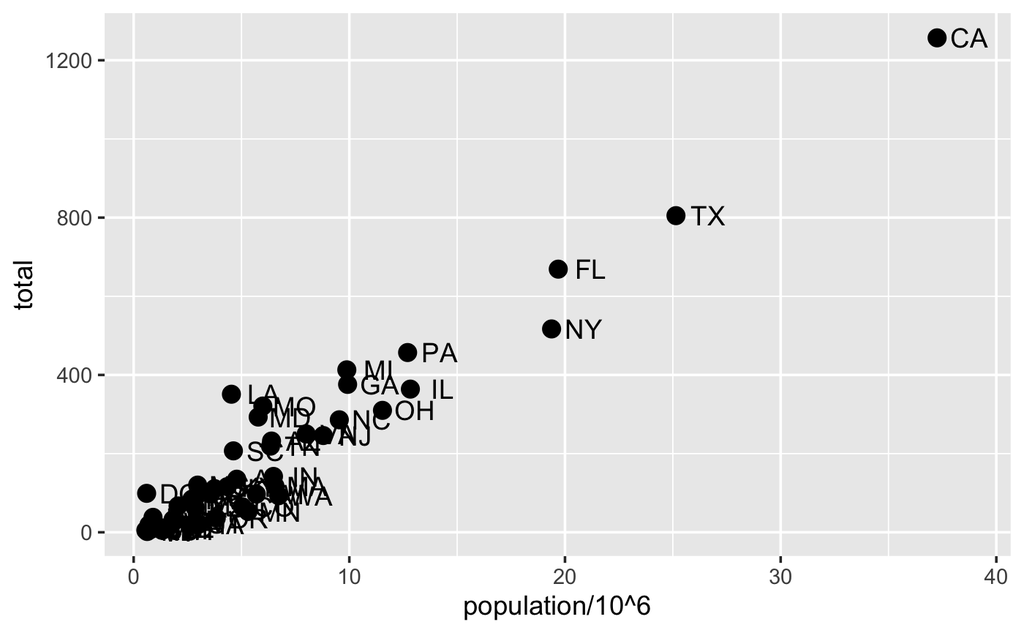

```r
p <- murders %>% ggplot(aes(population/10^6, total, label = abb))

p +
  geom_point(size = 3) +
  geom_text(nudge_x = 1.5)
```

#### Scales

Scales are another layer. Here we use the function `scale_x_continuous()` or `scale_y_continuous()` which are generic functions, but `scale_x_log10()` and `scale_y_log10()` can be used to simplify here.

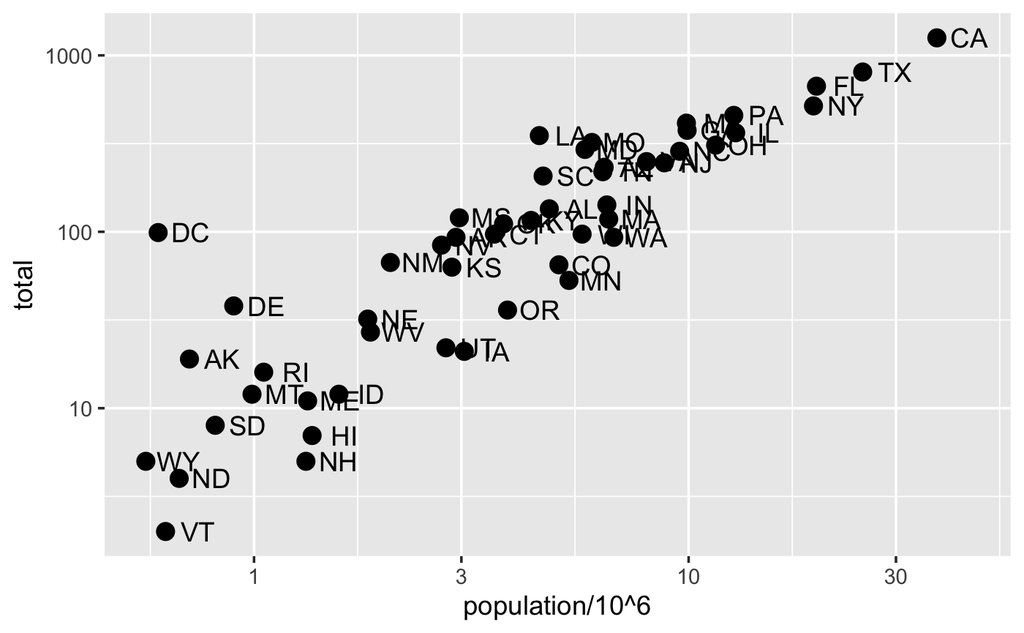

```r
p + geom_point(size = 3) +
  geom_text(nudge_x = 0.075) + # this value must be reduced for the log plot
  scale_x_continuous(trans = "log10") +
  scale_y_continuous(trans = "log10")
```

#### Labels & title

The functions are `xlab` and `ylab`

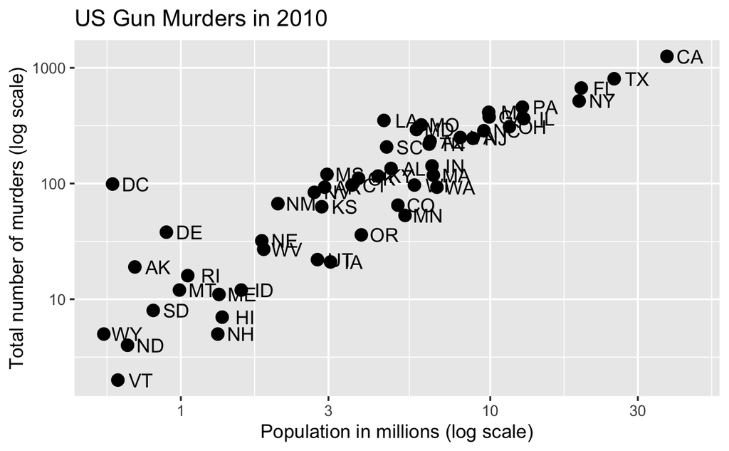

```r
p + geom_point(size = 3) +
    geom_text(nudge_x = 0.075) +
    scale_x_log10() +
    scale_y_log10() +
    xlab("Population in millions (log scale)") +
    ylab("Total number of murders (log scale)") +
    ggtitle("US Gun Murders in 2010")
```

#### Colours

Redefining `p` to include everything except the points layer. Then we can define the points layer, with a colour mapping, according to a categorical variable. The `x` and `y` mappings are already defined in the function call to `ggplot()` here.

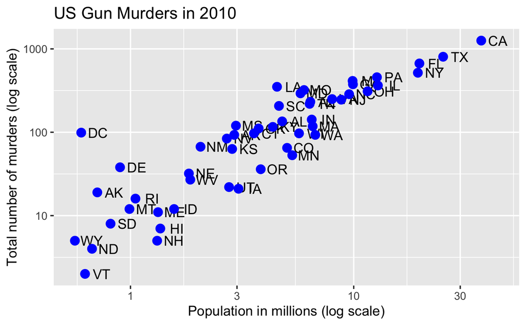

```r
# redefine p to be everything except the points layer
p <- murders %>%
    ggplot(aes(population/10^6, total, label = abb)) +
    geom_text(nudge_x = 0.075) +
    scale_x_log10() +
    scale_y_log10() +
    xlab("Population in millions (log scale)") +
    ylab("Total number of murders (log scale)") +
    ggtitle("US Gun Murders in 2010")

# make all points blue
p + geom_point(size = 3, color = "blue")
```

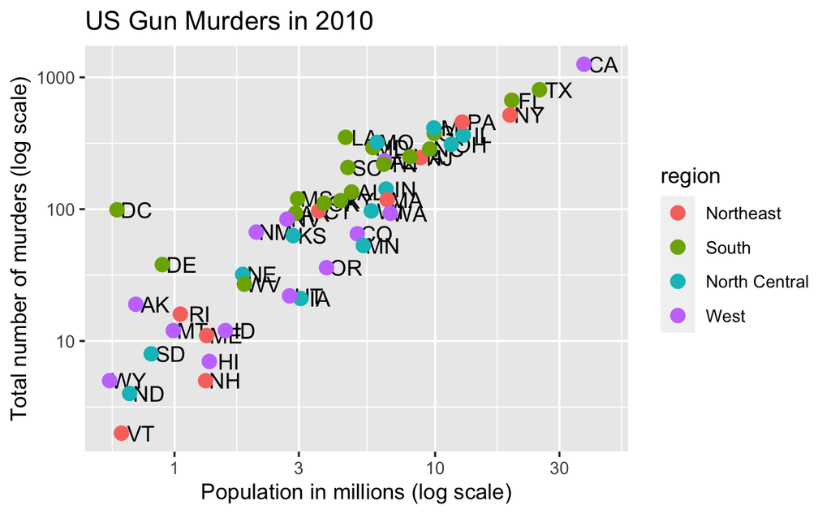

```r
# color points by region
p + geom_point(aes(col = region), size = 3)
```

#### Lines

If we want to combine data on a graph, such as adding a line, it can simply be added as a new layer. Here the average murder rate is calculated from `data(murders)`, and the function `geom_abline()` describes the layer. Note that for the second plot where a dashed grey line is use, the line is added before the data, as the ordering defines the visual overlapping of layers on the plot.

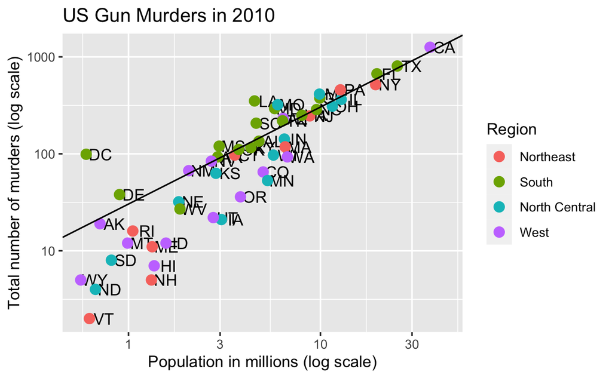

```r
# define average murder rate
r <- murders %>%
    summarize(rate = sum(total) / sum(population) * 10^6) %>%
    pull(rate)

# basic line with average murder rate for the country
p + geom_point(aes(col = region), size = 3) +
    geom_abline(intercept = log10(r)) +    # slope is default of 1
    scale_color_discrete(name = "Region") # capitalise legend title
```

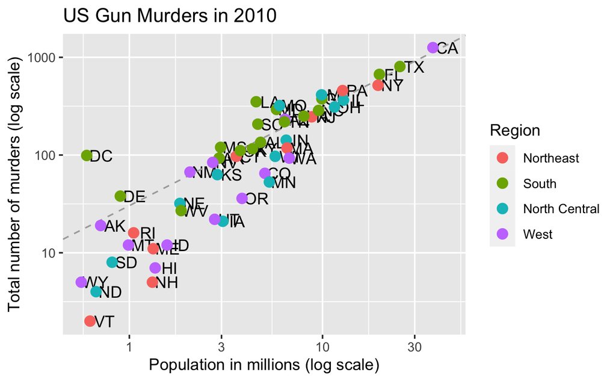

```r
# change line to dashed and dark grey, line under points
p +
    geom_abline(intercept = log10(r), lty = 2, color = "darkgrey") +
    geom_point(aes(col = region), size = 3) +
    scale_color_discrete(name = "Region")
```

##### Legend title

In the previous plots, note that we added this layer to our plot object to capitalise the legend title.

`scale_color_discrete(name = "Region") # capitalize legend title`

## Add-on Packages

Add-on packages provide additional features that fit well with the grammar in `ggplot`. Here they are simply added

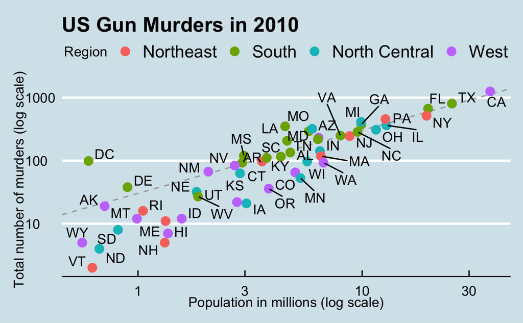

```r
library(dslabs)
library(ggthemes)
library(ggrepel)
ds_theme_set()

# define the intercept
r <- murders %>%
    summarize(rate = sum(total) / sum(population) * 10^6) %>%
    .$rate

# make the plot, combining all elements
p <- murders %>%
    ggplot(aes(population/10^6, total, label = abb)) +
    geom_abline(intercept = log10(r), lty = 2, color = "darkgrey") +
    geom_point(aes(col = region), size = 3) +
    geom_text_repel() +
    scale_x_log10() +
    scale_y_log10() +
    xlab("Population in millions (log scale)") +
    ylab("Total number of murders (log scale)") +
    ggtitle("US Gun Murders in 2010") +
    scale_color_discrete(name = "Region")

# themes from ggthemes
p + theme_economist()    # style of the Economist magazine
```

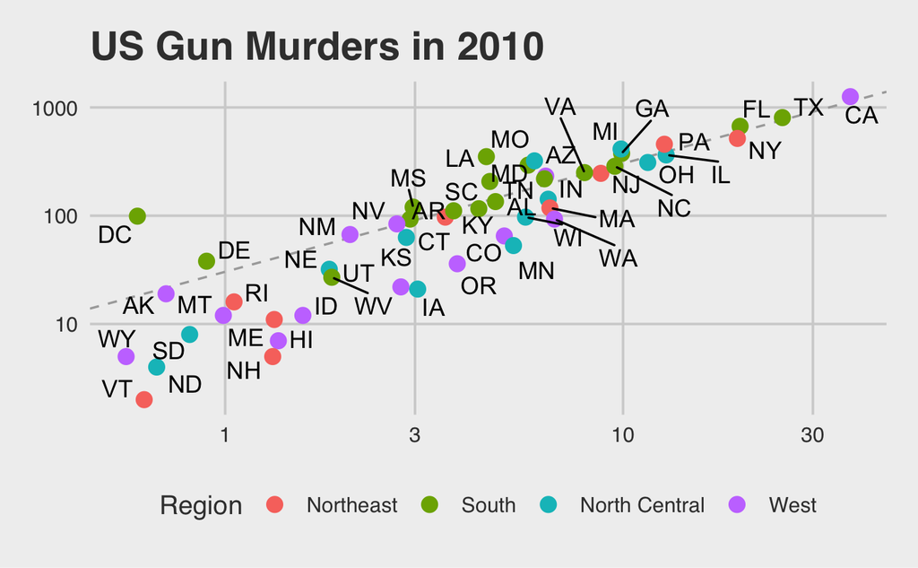

```r
p + theme_fivethirtyeight()    # style of the FiveThirtyEight website
```

## `ggplot` Examples based on Distributions notebook (`01.md`)

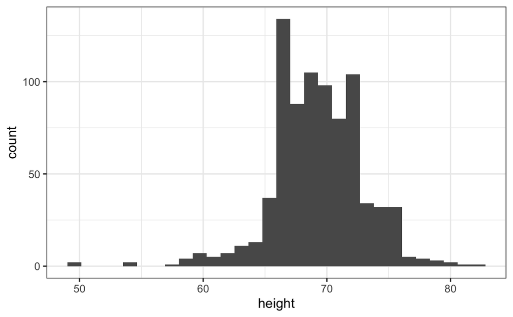

```r
# load heights data
library(tidyverse)
library(dslabs)
data(heights)

# define p
p <- heights %>%
    filter(sex == "Male") %>%
    ggplot(aes(x = height))

# basic histograms
p + geom_histogram()
```

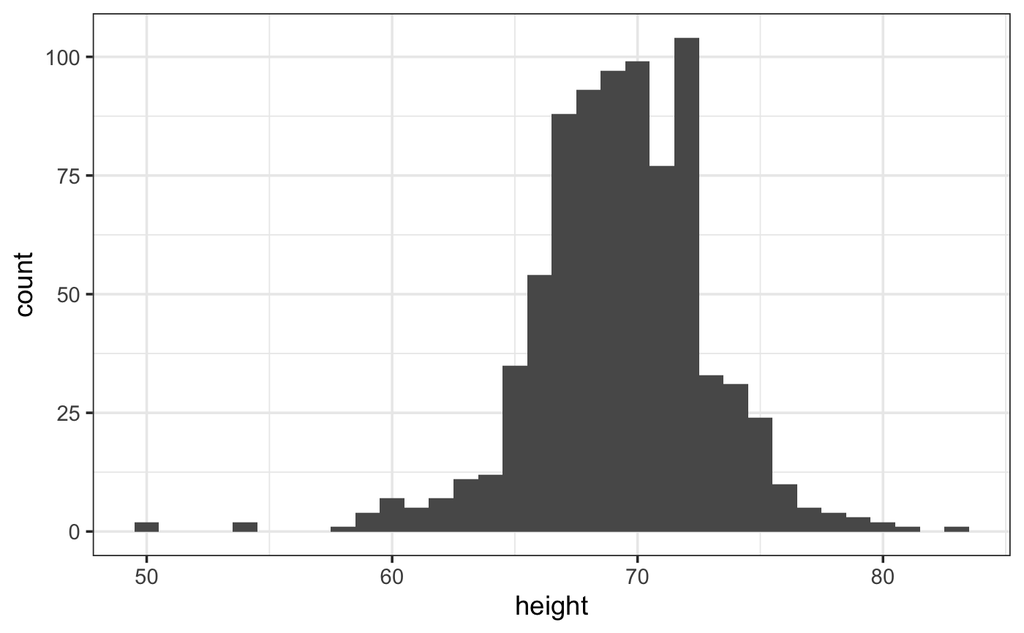

```r
p + geom_histogram(binwidth = 1)
```

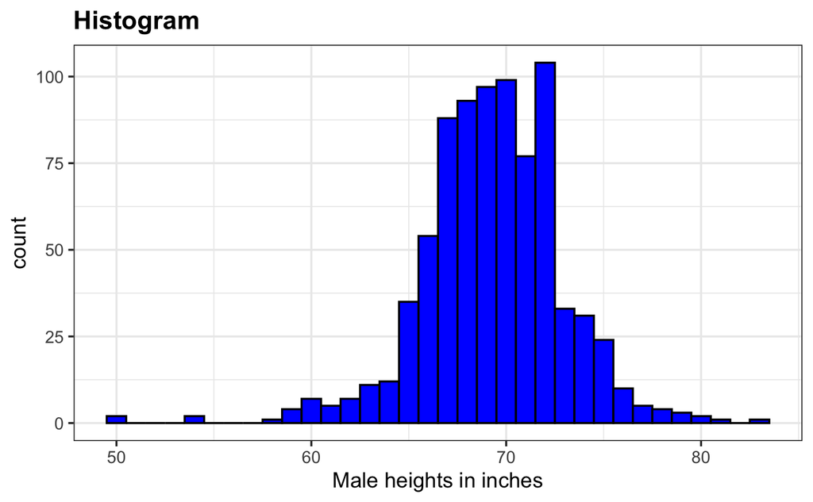

```r
# histogram with blue fill, black outline, labels and title
p + geom_histogram(binwidth = 1, fill = "blue", col = "black") +
    xlab("Male heights in inches") +
    ggtitle("Histogram")
```

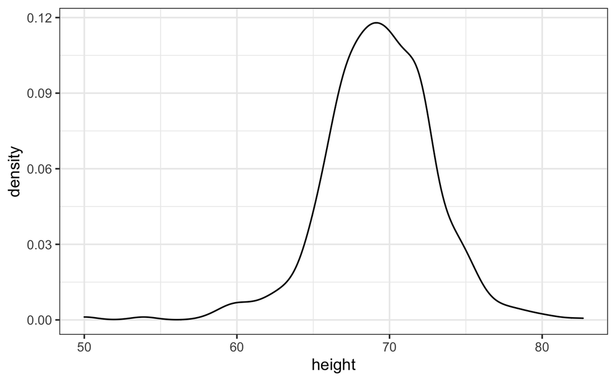

```r
p + geom_density()
```

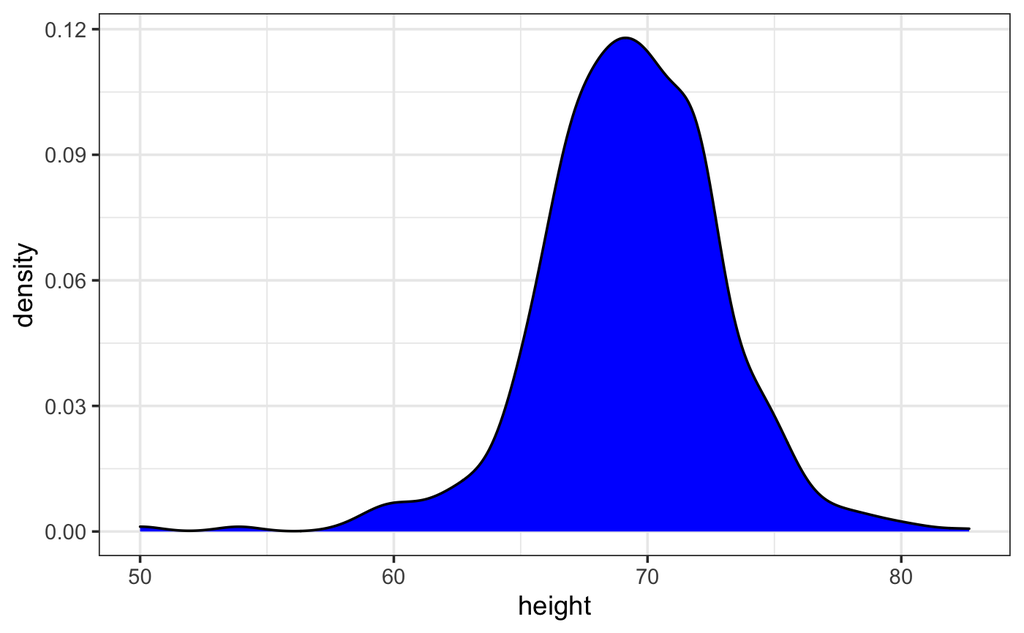

```r
p + geom_density(fill = "blue")
```

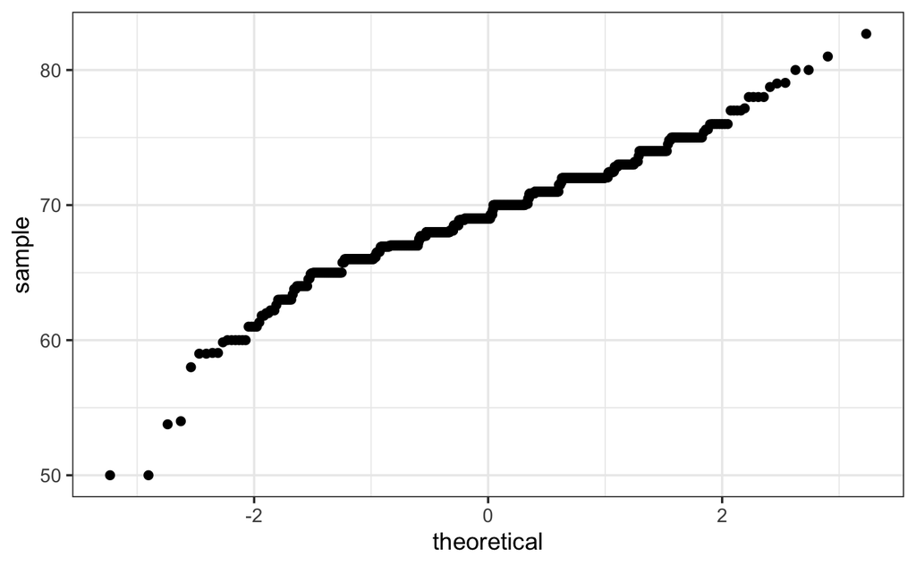

```r
# basic QQ-plot
p <- heights %>% filter(sex == "Male") %>%
    ggplot(aes(sample = height))
p + geom_qq()
```

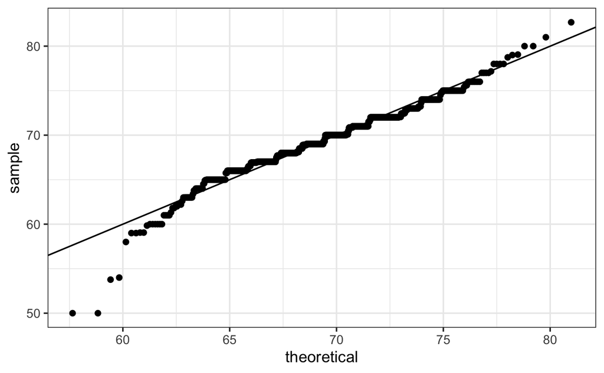

```r
# QQ-plot against a normal distribution with same mean/sd as data
params <- heights %>%
    filter(sex == "Male") %>%
    summarize(mean = mean(height), sd = sd(height))
    p + geom_qq(dparams = params) +
    geom_abline()
```

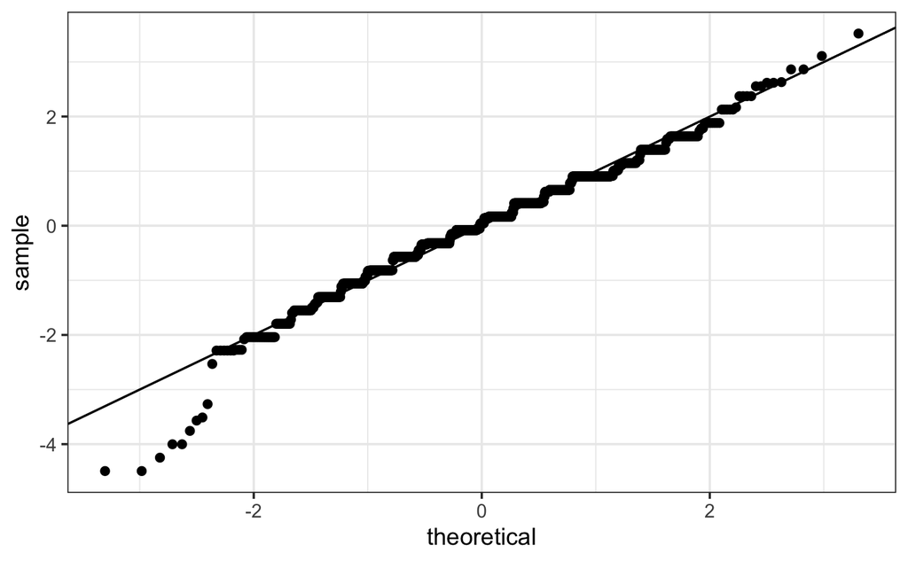

```r
# QQ-plot of scaled data against the standard normal distribution
heights %>%
    ggplot(aes(sample = scale(height))) +
    geom_qq() +
    geom_abline()
```

### Combining plots

Using the `gridExtra` package, plot objects can easily be combined.

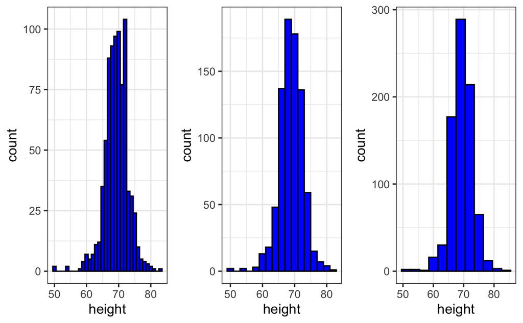

```r
# define plots p1, p2, p3
p <- heights %>% filter(sex == "Male") %>% ggplot(aes(x = height))
p1 <- p + geom_histogram(binwidth = 1, fill = "blue", col = "black")
p2 <- p + geom_histogram(binwidth = 2, fill = "blue", col = "black")
p3 <- p + geom_histogram(binwidth = 3, fill = "blue", col = "black")

# arrange plots next to each other in 1 row, 3 columns
library(gridExtra)
grid.arrange(p1, p2, p3, ncol = 3)
```